## Исследование выбранной модели

```r
ols_vif_tol(step_model)
```

```
##    Variables Tolerance      VIF
## 1      Sport 0.7159708 1.396705
## 2  SportUtil 0.7521953 1.329442
## 3     Pickup 0.8760115 1.141538
## 4  All_wheel 0.6738730 1.483959
## 5 Rear_wheel 0.6051166 1.652574
## 6  Cylinders 0.3550471 2.816528
## 7 Horsepower 0.3180643 3.144018
```

Все показатели VIF меньше 5, значит, мультиколлинеарности нет.

```r
ols_correlations(step_model)
```

```
##                 Correlations
## ---------------------------------------------
## Variable      Zero Order    Partial     Part
## ---------------------------------------------
## Sport              0.338      0.101     0.045
## SportUtil          0.098     -0.117    -0.052
## Pickup            -0.106     -0.375    -0.178
## All_wheel          0.180      0.266     0.122
## Rear_wheel         0.403      0.247     0.113
## Cylinders          0.702      0.166     0.075
## Horsepower         0.867      0.662     0.390
## ---------------------------------------------
```

*Residuals vs predicted*

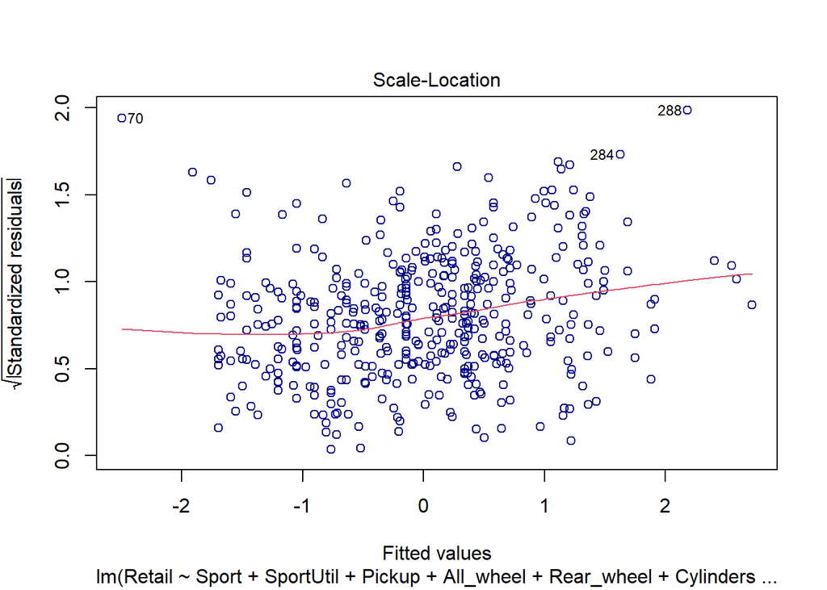

```r
plot(step_model, which=3, col=c("darkblue"))
```

Pасположение остатков по линейной регрессии на графике будет отражать характер зависимости между регрессорами и зависимой переменной. В идеальной ситуации остатки должны случайно распределяться вокруг нуля без каких-либо видимых закономерностей. Однако если на графике видны какие-либо закономерности, это может указывать на наличие гетероскедастичности, проблему спецификации. Также на этом графике можно увидеть выбросы.

*Нормальность остатков*

**Зачем нужна нормальность остатков**

1. Для проверки гипотез, тогда критерии будут точными.
2. В случае нормальности оценка OLS совпадает с оценкой MLE. Тогда полученная оценка коэффициентов регрессии будет асимптотически эффективной (по свойствам MLE).

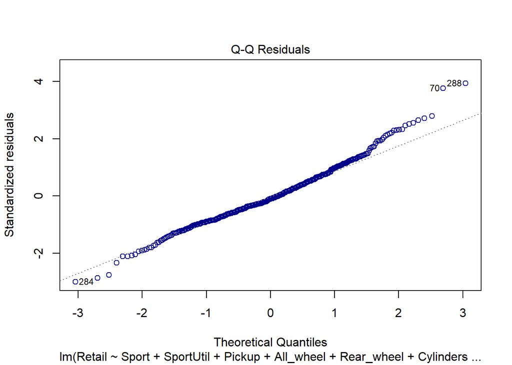

```r
plot(step_model, which=2, col=c("darkblue"))
```

Точки отклоняются от линии на концах (в начале и в конце графика), это может свидетельствовать о наличие тяжелых хвостов в распределении остатков, т.е. о наличии выбросов или нарушении нормальности.

*Гистограмма остатков*

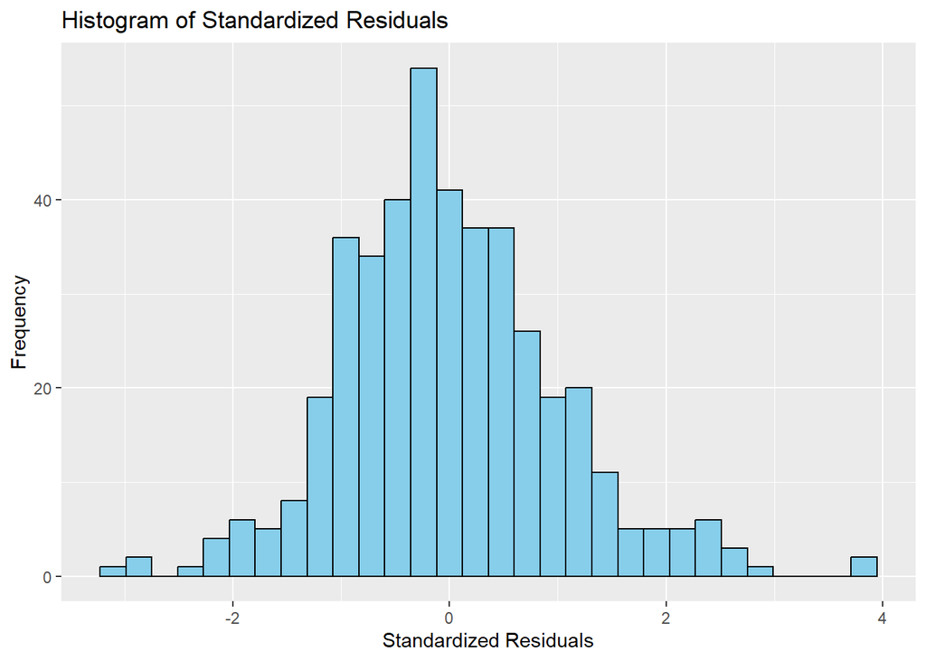

```r
ggplot(data.frame(Standardized_Residuals = rstandard(step_model)),
       aes(x = Standardized_Residuals)) +
       geom_histogram(fill = "skyblue", color = "black", aes(y = ..count..)) +
       labs(title = "Histogram of Standardized Residuals", x = "Standardized Residuals", y = "Frequency")
```

Из гистограммы видно, что распределение остатков несильно отличается от нормального, значит, можно считать, что остатки распределены нормально.

*Externally Studentized vs Internally Studentized residuals*

Internally studentized: $\frac{r_i}{\hat{\sigma} \sqrt{1-h_{ii}}}.$

Externally studentized: $\frac{r_i}{\hat{\sigma}^{(i)} \sqrt{1-h_{ii}}}.$

То есть по сути сравниваются дисперсии.

Данный график позволяет выявить наличие выбросов и наблюдений с высоким влиянием.

Так как нет точек, находящихся далеко от прямой y=x, то можно сказать, что дисперсии примерно равны. На “хвостах” графика есть точки, отстаящие от остальных, что свидеьельствует о том, что они могут являться выбросами.

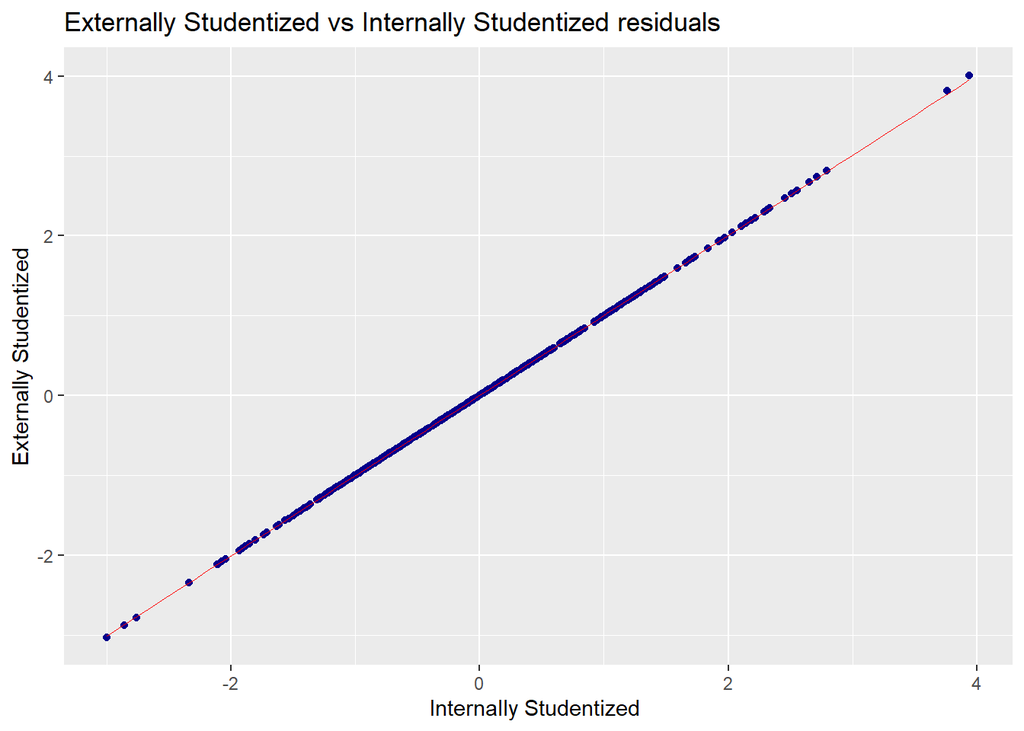

```r
data_res <- data.frame(Internally_Studentized = rstandard(step_model), Externally_Studentized = rstudent(step_model))

ggplot(data_res, aes(x = Internally_Studentized, y = Externally_Studentized)) +
  geom_point(color = "darkblue") +
  geom_smooth(method = "lm", se = FALSE, color = "red", lwd = 0.1) +
  labs(title = "Externally Studentized vs Internally Studentized residuals", x = "Internally Studentized ", y = "Externally Studentized")
```

## Выбросы по Куку

Расстояние по Куку показывает выбросы по отношению к регрессии, оно измеряет влияние каждого наблюдения на оценки коэффициентов регрессии.

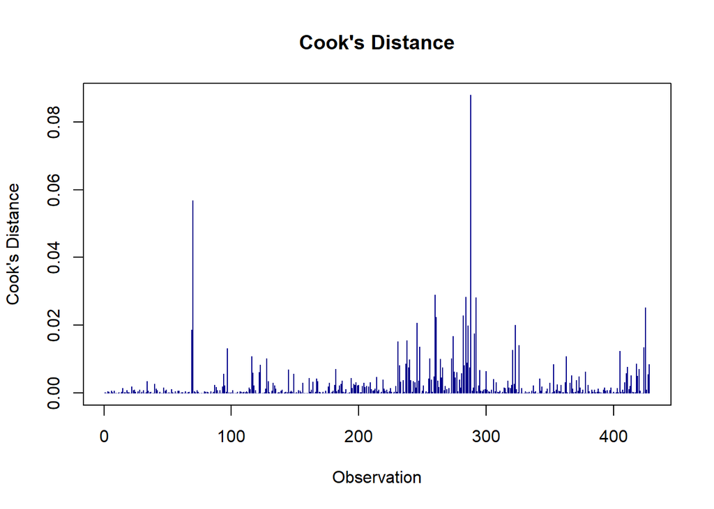

```r
cooks_distance <- cooks.distance(step_model)

plot(cooks_distance,
     col = "darkblue",
     type = "h",
     main = "Cook's Distance",
     xlab = "Observation",
     ylab = "Cook's Distance")

abline(h = 1, col = "red", lty = 2)
```

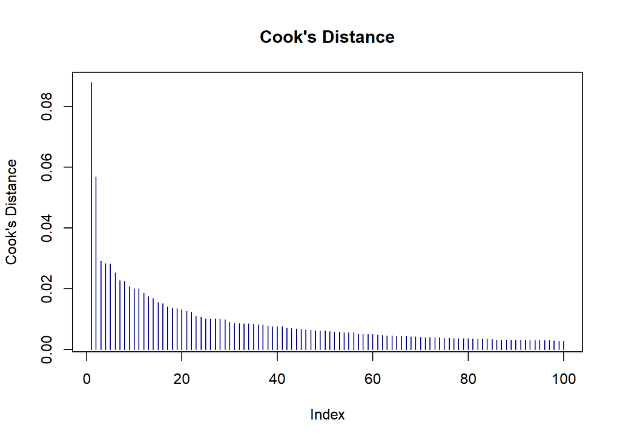

```r
sorted_indices <- order(cooks_distance, decreasing = TRUE)

plot(head(cooks_distance[sorted_indices], 100),
     col = "darkblue",
     type = "h",
     main = "Cook's Distance",
     ylab = "Cook's Distance")

abline(h = 1, col = "red", lty = 2)
```

На основе этого графика можно сказать, что наблюдения 70 и 288 являются выбросами, так как для них происходит скачок при изображении расстояний.

## Выбросы по Махаланобису

Расстояние по Махаланобису показывает выбросы по отношению к распределению регрессоров.

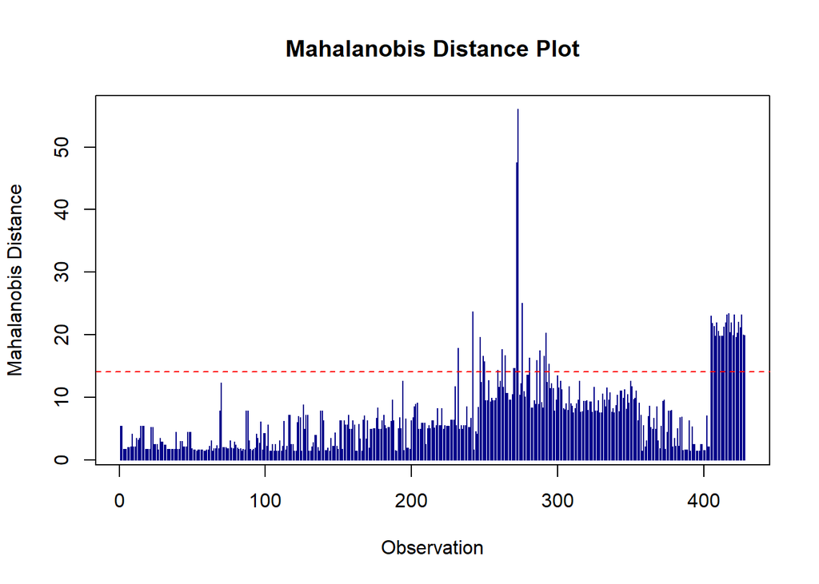

```r
selected_cols <- c("Sport", "SportUtil", "Pickup", "All_wheel", "Rear_wheel", "Cylinders", "Horsepower")
selected_data <- data_log[, selected_cols]
cov_matrix <- cov(selected_data)

mahalanobis_distance <- mahalanobis(selected_data, center = colMeans(selected_data), cov = cov_matrix)

threshold <- qchisq(0.95, length(selected_cols))

plot(mahalanobis_distance,
     main = "Mahalanobis Distance Plot",
     xlab = "Observation",
     ylab = "Mahalanobis Distance",
     type = "h",
     col = "darkblue")

abline(h = threshold, col = "red", lty = 2)
```

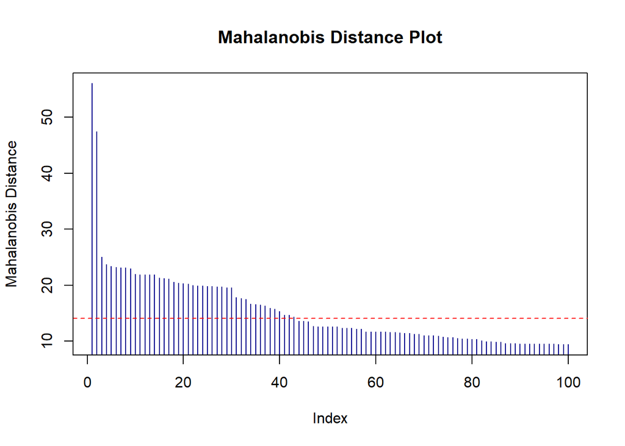

```r
ordered_indices <- order(mahalanobis_distance, decreasing = TRUE)

plot(head(mahalanobis_distance[ordered_indices], 100),
     main = "Mahalanobis Distance Plot",
     ylab = "Mahalanobis Distance",
     type = "h",
     col = "darkblue")

abline(h = threshold, col = "red", lty = 2)
```

На основе этого графика можно сказать, что наблюдения 272 и 273 являются выбросами, так как для них происходит скачок при изображении расстояний.

## RStudent vs Leverage

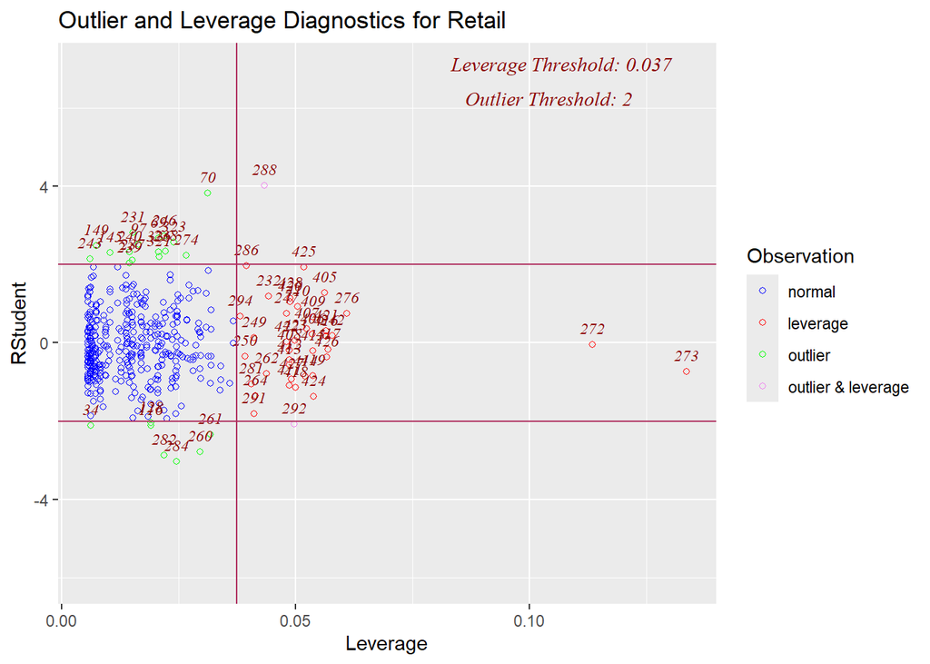

```r
ols_plot_resid_lev(step_model)
```

Оси графика:

1. Ось X (“Leverage”): Показывает значение плеча влияния для каждого наблюдения. Плечо влияния отражает потенциальное влияние каждого наблюдения на оценки параметров модели. Высокие значения плеча влияния указывают на то, что наблюдение имеет большое влияние на модель.
2. Ось Y (“RStudent”): Показывает стьюдентизированные остатки (остатки, делённые на оценку их стандартного отклонения, учитывая число степеней свободы).

На основе данного графика можно заключить, что выбросами являются наблюдения 70, 272, 273, 288, что согласуется с тем, какие выбросы были получены на основе графиков расстояний по Куку и по Махаланобису.

## Выбросы

```r
selected_rows <- data[c(70, 272, 273, 288), ]
print_df(selected_rows)
```

| Name | Sport | SportUtil | Wagon | Minivan | Pickup | All_wheel | Rear_wheel | Retail | Dealer | Engine | Cylinders | Horsepower | CityMPG | HW_MPG | Weight | WheelBase | Length | Width |
| --- | --- | --- | --- | --- | --- | --- | --- | --- | --- | --- | --- | --- | --- | --- | --- | --- | --- | --- |
| Honda Insight 2dr (gas/electric) | 0 | 0 | 0 | 0 | 0 | 0 | 0 | 19110 | 17911 | 2.0 | 3 | 73 | 60 | 66 | 1850 | 95 | 155 | 67 |
| Mazda RX-8 4dr automatic | 1 | 0 | 0 | 0 | 0 | 0 | 1 | 25700 | 23794 | 1.3 | -1 | 197 | 18 | 25 | 3053 | 106 | 174 | NA |
| Mazda RX-8 4dr manual | 1 | 0 | 0 | 0 | 0 | 0 | 1 | 27200 | 25179 | 1.3 | -1 | 238 | 18 | 24 | 3029 | 106 | 174 | NA |
| Porsche 911 GT2 2dr | 1 | 0 | 0 | 0 | 0 | 0 | 1 | 192465 | 173560 | 3.6 | 6 | 477 | 17 | 24 | 3131 | 93 | 175 | 72 |

На основе анализа прошлого семестра эти наблюдения были также выявлены как выбросы и вот почему:

1. У 70 высокое mpg, так как Honda Insight 2dr является гибридными автомобилем (такие автомобили используют комбинацию бензинового двигателя и электрической системы), это повышает эффективность топлива.

4. У 288 высокая цена и довольно низкое mpg. Porsche 911 GT2 –- спортивный автомобиль. Он не только по Retail и MPG является выбросом, но и по Horsepower (477 (не в log шкале) -– это очень много, по сравнению с остальными автомобилями).

*Построим модель без выбросов*

```r
data_log <- data %>%
  mutate_at(vars(Retail, Dealer, Engine, Horsepower, CityMPG, HW_MPG, Weight, WheelBase), ~log(.))

data_log_clean <- data_log[-c(70, 272, 273, 288), ]

new_model <- lm(Retail ~ Sport + SportUtil + Pickup +  All_wheel +  Rear_wheel +
                     Cylinders + Horsepower, data = data_log_clean)
summary(new_model)
```

```
##
## Call:
## lm(formula = Retail ~ Sport + SportUtil + Pickup + All_wheel +
##     Rear_wheel + Cylinders + Horsepower, data = data_log_clean)
##
## Residuals:
##      Min       1Q   Median       3Q      Max
## -0.62801 -0.13368 -0.01974  0.12893  0.60194
##
## Coefficients:
##             Estimate Std. Error t value Pr(>|t|)
## (Intercept)  4.51640    0.26151  17.271  < 2e-16 ***
## Sport        0.06752    0.03779   1.787  0.07473 .
## SportUtil   -0.08417    0.03388  -2.484  0.01337 *
## Pickup      -0.40122    0.04716  -8.508 3.24e-16 ***
## All_wheel    0.17774    0.03013   5.899 7.59e-09 ***
## Rear_wheel   0.15930    0.03018   5.278 2.11e-07 ***
## Cylinders    0.03805    0.01198   3.176  0.00161 **
## Horsepower   1.02930    0.05932  17.351  < 2e-16 ***
## ---
## Signif. codes:  0 '***' 0.001 '**' 0.01 '*' 0.05 '.' 0.1 ' ' 1
##
## Residual standard error: 0.2101 on 416 degrees of freedom
## Multiple R-squared:  0.8114, Adjusted R-squared:  0.8082
## F-statistic: 255.6 on 7 and 416 DF,  p-value: < 2.2e-16
```

Значения Multiple R-squared и Adjusted R-squared совсем немного, но увеличились.

**Предскажем что-то по модели**

```r
new_data <- data.frame(
  Sport = 1,
  SportUtil = 0,
  Pickup = 0,
  All_wheel = 0,
  Rear_wheel = 1,
  Cylinders = 4,
  Horsepower = log(200)
)

prediction <- predict(new_model, newdata = new_data)

print(exp(prediction))
```

```
##        1
## 31224.07
```

Посмотрим на цены автомобилей с похожими характеристиками.

```r
subset_data <- data[data$Horsepower >= 200 & data$Horsepower < 250 & data$Sport == 1 & data$Rear_wheel == 1, ]
print_df(subset_data)
```

| Name | Sport | SportUtil | Wagon | Minivan | Pickup | All_wheel | Rear_wheel | Retail | Dealer | Engine | Cylinders | Horsepower | CityMPG | HW_MPG | Weight | WheelBase | Length | Width |
| --- | --- | --- | --- | --- | --- | --- | --- | --- | --- | --- | --- | --- | --- | --- | --- | --- | --- | --- |
| BMW Z4 convertible 3.0i 2dr | 1 | 0 | 0 | 0 | 0 | 0 | 1 | 41045 | 37575 | 3.0 | 6 | 225 | 21 | 29 | 2998 | 98 | 161 | 70 |
| Chrysler Crossfire 2dr | 1 | 0 | 0 | 0 | 0 | 0 | 1 | 34495 | 32033 | 3.2 | 6 | 215 | 17 | 25 | 3060 | 95 | 160 | 70 |
| Honda S2000 convertible 2dr | 1 | 0 | 0 | 0 | 0 | 0 | 1 | 33260 | 29965 | 2.2 | 4 | 240 | 20 | 25 | 2835 | 95 | 162 | 69 |
| Mazda RX-8 4dr manual | 1 | 0 | 0 | 0 | 0 | 0 | 1 | 27200 | 25179 | 1.3 | -1 | 238 | 18 | 24 | 3029 | 106 | 174 | NA |
| Porsche Boxster convertible 2dr | 1 | 0 | 0 | 0 | 0 | 0 | 1 | 43365 | 37886 | 2.7 | 6 | 228 | 20 | 29 | 2811 | 95 | 170 | 70 |

Полученный прогноз кажется хорошо согласуется с данными и отражает цену, которая может быть у автомобиля с данными характеристиками.

*Доверительный и предсказательный интервал*

```r
confidence_int <- predict(new_model, newdata = new_data, interval = "confidence", level = 0.95)
print(exp(confidence_int))
```

```
##        fit      lwr      upr
## 1 31224.07 28970.75 33652.65
```

Доверительный интервал является оценкой диапазона, в котором, с заданным уровнем доверия, находится среднее значение прогнозируемой переменной.

Используется для оценки неопределенности вокруг среднего значения прогнозируемой переменной.

```r
prediction_int <- predict(new_model, newdata = new_data, interval = "prediction", level = 0.95)
print(exp(prediction_int))
```

```
##        fit      lwr      upr
## 1 31224.07 20522.45 47506.15
```

Предсказательный интервал является оценкой диапазона, в котором, с заданной вероятностью, находится будущее наблюдение.

Используется для оценки неопределенности вокруг прогноза для нового наблюдения.

Ширина предсказательного интервала больше, чем ширина доверительного интервала, так как он включает в себя случайную ошибку модели.